# Diabetic Application- Case Study

### Diabetic case Study

Diabetes is a disease which occurs when the blood glucose level becomes high, which ultimately leads to other health problems such as heart diseases, kidney disease etc.

Diabetes is caused mainly due to the consumption of highly processed food, bad consumption habits etc.

According to WHO, the number of people with diabetes has been increased over the years.

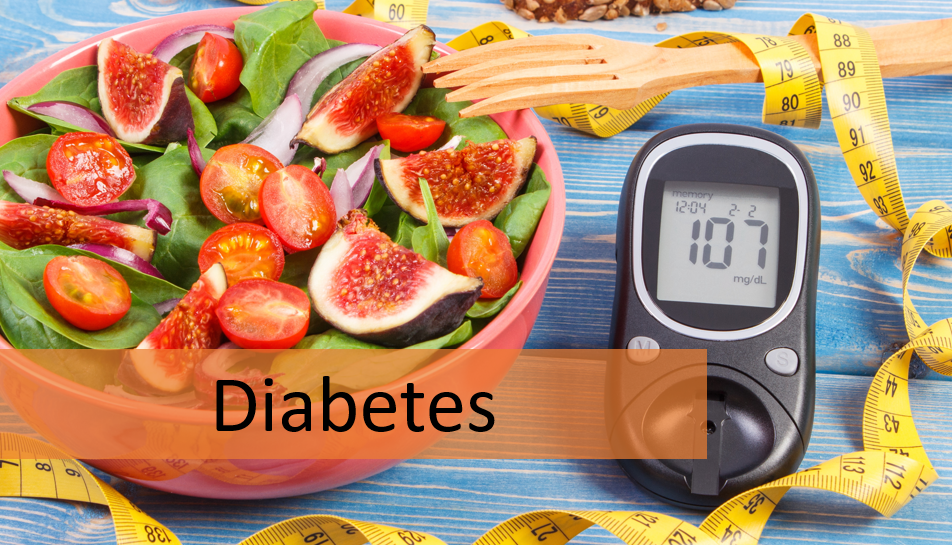

```python
from IPython.display import Image
Image(filename='1.png')
```

##### The datasets consists of several medical predictor variables and one target variable, Outcome.

Pregnancies :- Number of times pregnant

Glucose:- Plasma glucose concentration a 2 hours in an oral glucose tolerance test

BloodPressure:- Diastolic blood pressure

SkinThickness:- Triceps skin fold thickness

Insulin:- 2-Hour serum insulin

BMI:- Body mass index

DiabetesPedigreeFunction:- Diabetes pedigree function

Age:-Age in years

Outcome:- Class variable (0 or 1)

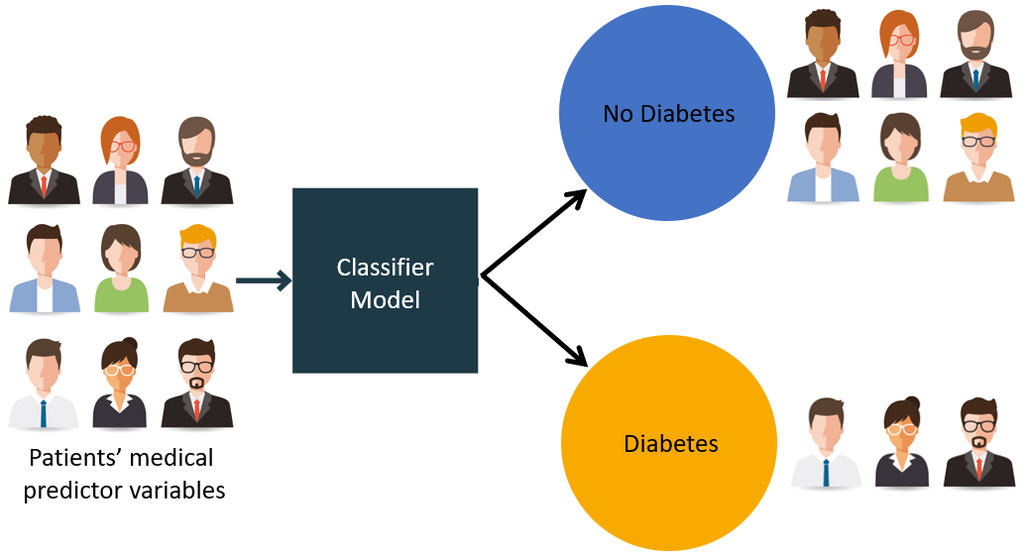

```python
from IPython.display import Image
Image(filename='2.png')
```

### Load Data

```python
import pandas as pd
import numpy as np

my_data = pd.read_csv("diabetes.csv")
```

```python
my_data.shape
```

```
(768, 9)
```

```python
types = my_data.dtypes
types
```

```
Pregnancies                   int64
Glucose                       int64
BloodPressure                 int64
SkinThickness                 int64
Insulin                       int64
BMI                         float64
DiabetesPedigreeFunction    float64
Age                           int64
Outcome                       int64
dtype: object
```

```python
my_data.columns
```

```
Index(['Pregnancies', 'Glucose', 'BloodPressure', 'SkinThickness', 'Insulin',
       'BMI', 'DiabetesPedigreeFunction', 'Age', 'Outcome'],
      dtype='object')
```

```python
my_data.head()
```

|  | Pregnancies | Glucose | BloodPressure | SkinThickness | Insulin | BMI | DiabetesPedigreeFunction | Age | Outcome |
| --- | --- | --- | --- | --- | --- | --- | --- | --- | --- |
| 0 | 6 | 148 | 72 | 35 | 0 | 33.6 | 0.627 | 50 | 1 |
| 1 | 1 | 85 | 66 | 29 | 0 | 26.6 | 0.351 | 31 | 0 |
| 2 | 8 | 183 | 64 | 0 | 0 | 23.3 | 0.672 | 32 | 1 |
| 3 | 1 | 89 | 66 | 23 | 94 | 28.1 | 0.167 | 21 | 0 |
| 4 | 0 | 137 | 40 | 35 | 168 | 43.1 | 2.288 | 33 | 1 |

### Missing Values

```python
my_data.isnull().sum()
```

```
Pregnancies                 0
Glucose                     0
BloodPressure               0
SkinThickness               0
Insulin                     0
BMI                         0
DiabetesPedigreeFunction    0
Age                         0
Outcome                     0
dtype: int64
```

```python
my_data.info()
```

```
<class 'pandas.core.frame.DataFrame'>
RangeIndex: 768 entries, 0 to 767
Data columns (total 9 columns):
 #   Column                    Non-Null Count  Dtype
---  ------                    --------------  -----
 0   Pregnancies               768 non-null    int64
 1   Glucose                   768 non-null    int64
 2   BloodPressure             768 non-null    int64
 3   SkinThickness             768 non-null    int64
 4   Insulin                   768 non-null    int64
 5   BMI                       768 non-null    float64
 6   DiabetesPedigreeFunction  768 non-null    float64
 7   Age                       768 non-null    int64
 8   Outcome                   768 non-null    int64
dtypes: float64(2), int64(7)
memory usage: 54.1 KB
```

```python
my_data.describe()
```

|  | Pregnancies | Glucose | BloodPressure | SkinThickness | Insulin | BMI | DiabetesPedigreeFunction | Age | Outcome |
| --- | --- | --- | --- | --- | --- | --- | --- | --- | --- |
| count | 768.000000 | 768.000000 | 768.000000 | 768.000000 | 768.000000 | 768.000000 | 768.000000 | 768.000000 | 768.000000 |
| mean | 3.845052 | 120.894531 | 69.105469 | 20.536458 | 79.799479 | 31.992578 | 0.471876 | 33.240885 | 0.348958 |
| std | 3.369578 | 31.972618 | 19.355807 | 15.952218 | 115.244002 | 7.884160 | 0.331329 | 11.760232 | 0.476951 |
| min | 0.000000 | 0.000000 | 0.000000 | 0.000000 | 0.000000 | 0.000000 | 0.078000 | 21.000000 | 0.000000 |
| 25% | 1.000000 | 99.000000 | 62.000000 | 0.000000 | 0.000000 | 27.300000 | 0.243750 | 24.000000 | 0.000000 |
| 50% | 3.000000 | 117.000000 | 72.000000 | 23.000000 | 30.500000 | 32.000000 | 0.372500 | 29.000000 | 0.000000 |
| 75% | 6.000000 | 140.250000 | 80.000000 | 32.000000 | 127.250000 | 36.600000 | 0.626250 | 41.000000 | 1.000000 |
| max | 17.000000 | 199.000000 | 122.000000 | 99.000000 | 846.000000 | 67.100000 | 2.420000 | 81.000000 | 1.000000 |

### Univariant and Bivariate Analysis

```python
my_data.groupby('Outcome').size()
```

```
Outcome
0    500
1    268
dtype: int64
```

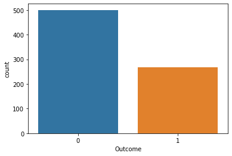

```python
import seaborn as sns
sns.countplot(my_data['Outcome'],label="Count")
```

```python
# Plasma glucose levels : Even after fasting glucose level would not be as low as zero.

print("Total : ", my_data[my_data.Glucose == 0].shape[0])

print(my_data[my_data.Glucose == 0].groupby('Outcome')['Age'].count())
```

```
Total :  5
Outcome
0    3
1    2
Name: Age, dtype: int64
```

```python
#Blood pressure : By observing the data we can see that there are 0 values for blood pressure.
# And it is evident that the readings of the data set seems wrong because a living person
# cannot have diastolic blood pressure of zero.

print("Total : ", my_data[my_data.BloodPressure == 0].shape[0])

print(my_data[my_data.BloodPressure == 0].groupby('Outcome')['Age'].count())
```

```
Total :  35
Outcome
0    19
1    16
Name: Age, dtype: int64
```

```python
# Skin Fold Thickness : For normal people skin fold thickness can’t be less than 10 mm better yet zero.

print("Total : ", my_data[my_data.SkinThickness == 0].shape[0])

print(my_data[my_data.SkinThickness == 0].groupby('Outcome')['Age'].count())
```

```
Total :  227
Outcome
0    139
1     88
Name: Age, dtype: int64
```

```python
#BMI : Should not be 0 or close to zero unless the person is really underweight which could be life threatening.

print("Total : ", my_data[my_data.BMI == 0].shape[0])

print(my_data[my_data.BMI == 0].groupby('Outcome')['Age'].count())
```

```
Total :  11
Outcome
0    9
1    2
Name: Age, dtype: int64
```

```python
#Insulin : In a rare situation a person can have zero insulin

print("Total : ", my_data[my_data.Insulin == 0].shape[0])

print(my_data[my_data.Insulin == 0].groupby('Outcome')['Age'].count())
```

```
Total :  374
Outcome
0    236
1    138
Name: Age, dtype: int64
```

## handle invalid data values :

Ignore/remove these cases : This is not actually possible in most cases because that would mean losing valuable information.

And in this case “skin thickness” and “insulin” columns means have a lot of invalid points. But it might work for “BMI”, “glucose ”and “blood pressure” data points.

Put average/mean values : This might work for some data sets, but in our case putting a mean value to the blood pressure column would send a wrong signal to the model.

Avoid using features : It is possible to not use the features with a lot of invalid values for the model. This may work for “skin thickness” but its hard to predict that.

```python
#remove the rows which the “BloodPressure”, “BMI” and “Glucose” are zero.

my_data = my_data[(my_data.BloodPressure != 0) & (my_data.BMI != 0) & (my_data.Glucose != 0)]
print(my_data.shape)
```

```
(724, 9)
```

### Transformation/Normalization

```python
from sklearn.preprocessing import MinMaxScaler
from numpy import set_printoptions
array = my_data.values
# separate array into input and output components
X = array[:,0:8]
Y = array[:,8]

scaler = MinMaxScaler(feature_range=(0, 1))
rescaledX = scaler.fit_transform(X)
print(rescaledX[0:5,:])
```

```
[[0.35294118 0.67096774 0.48979592 0.35353535 0.         0.31492843
  0.23441503 0.48333333]
 [0.05882353 0.26451613 0.42857143 0.29292929 0.         0.17177914
  0.11656704 0.16666667]
 [0.47058824 0.89677419 0.40816327 0.         0.         0.10429448
  0.25362938 0.18333333]
 [0.05882353 0.29032258 0.42857143 0.23232323 0.11111111 0.20245399
  0.03800171 0.        ]
 [0.         0.6        0.16326531 0.35353535 0.19858156 0.50920245
  0.94363792 0.2       ]]
```

```python
from sklearn.preprocessing import StandardScaler
from numpy import set_printoptions

scaler = StandardScaler().fit(rescaledX)
rescaledX_1 = scaler.transform(rescaledX)
set_printoptions(precision=3)
print(rescaledX_1[0:5,:])
```

```
[[ 0.635  0.85  -0.032  0.862 -0.723  0.165  0.458  1.416]
 [-0.853 -1.2   -0.517  0.481 -0.723 -0.852 -0.373 -0.2  ]
 [ 1.23   1.989 -0.679 -1.364 -0.723 -1.332  0.594 -0.115]
 [-0.853 -1.07  -0.517  0.099  0.081 -0.634 -0.927 -1.05 ]
 [-1.15   0.492 -2.619  0.862  0.714  1.545  5.46  -0.03 ]]
```

### EDA

Exploratory Data Analysis (EDA) is an approach to analyzing datasets to summarize their main characteristics, often with visual methods. EDA is used for seeing what the data can tell us before the modelling task.

### Histogram

Histograms group data into bins and provide you a count of the number of observations in each bin.

From the shape of the bins you can quickly get a feeling for whether an attribute is Gaussian, skewed or even has an exponential distribution.

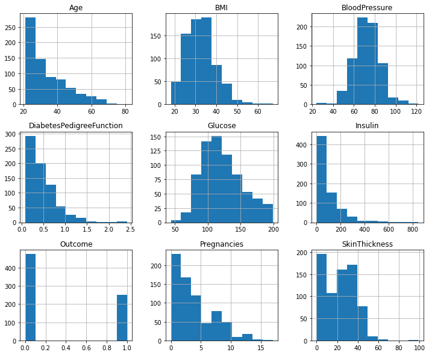

```python
from matplotlib import pyplot
%matplotlib inline
my_data.hist(figsize=(12,10))
pyplot.show()
```

```python
Note:
```

1. We can see that perhaps the attributes Age, DiabetesPedigreeFunction and Insulin may have an exponential distribution.
1. We can also see that perhaps the BMI and Blood Pressure and Glucose attributes may have a Gaussian or nearly Gaussian distribution.

### Desnsity plots

The plots look like an abstracted histogram with a smooth curve drawn through the top of each bin, much like your eye tried to do with the histograms.

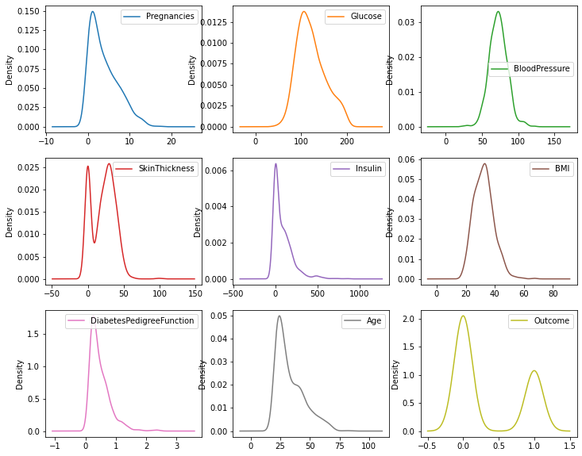

```python
my_data.plot(kind='density', subplots=True, layout=(3,3), sharex=False,figsize=(12,10))
pyplot.show()
```

### Box Plots

Boxplots summarize the distribution of each attribute, drawing a line for the median (middle value) and a box around the 25th and 75th percentiles (the middle 50% of the data).

The whiskers give an idea of the spread of the data and dots outside of the whiskers show candidate outlier values (values that are 1.5 times greater than the size of spread of the middle 50% of the data).

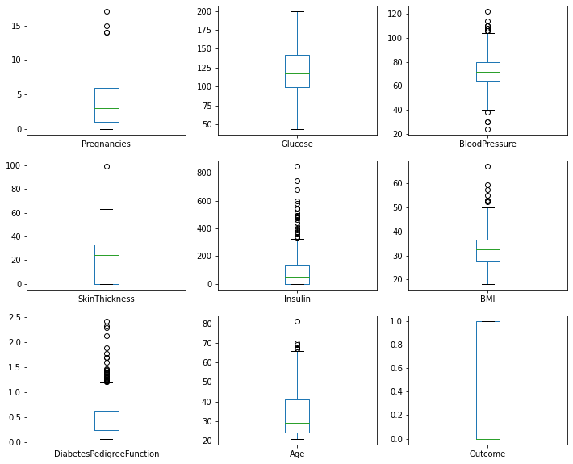

```python
my_data.plot(kind='box', subplots=True, layout=(3,3), sharex=False, sharey=False,figsize=(12,10))
pyplot.show()
```

Some like Age, Insulin and SkinThickness appear quite skewed towards smaller values.

### Correlation

Correlation gives an indication of how related the changes are between two variables.

If two variables change in the same direction they are positively correlated.

If they change in opposite directions together (one goes up, one goes down), then they are negatively correlated.

You can calculate the correlation between each pair of attributes.

This is called a correlation matrix.

```python
corr = my_data.corr()
corr
```

|  | Pregnancies | Glucose | BloodPressure | SkinThickness | Insulin | BMI | DiabetesPedigreeFunction | Age | Outcome |
| --- | --- | --- | --- | --- | --- | --- | --- | --- | --- |
| Pregnancies | 1.000000 | 0.134915 | 0.209668 | -0.095683 | -0.080059 | 0.012342 | -0.025996 | 0.557066 | 0.224417 |
| Glucose | 0.134915 | 1.000000 | 0.223331 | 0.074381 | 0.337896 | 0.223276 | 0.136630 | 0.263560 | 0.488384 |
| BloodPressure | 0.209668 | 0.223331 | 1.000000 | 0.011777 | -0.046856 | 0.287403 | -0.000075 | 0.324897 | 0.166703 |
| SkinThickness | -0.095683 | 0.074381 | 0.011777 | 1.000000 | 0.420874 | 0.401528 | 0.176253 | -0.128908 | 0.092030 |
| Insulin | -0.080059 | 0.337896 | -0.046856 | 0.420874 | 1.000000 | 0.191831 | 0.182656 | -0.049412 | 0.145488 |
| BMI | 0.012342 | 0.223276 | 0.287403 | 0.401528 | 0.191831 | 1.000000 | 0.154858 | 0.020835 | 0.299375 |
| DiabetesPedigreeFunction | -0.025996 | 0.136630 | -0.000075 | 0.176253 | 0.182656 | 0.154858 | 1.000000 | 0.023098 | 0.184947 |
| Age | 0.557066 | 0.263560 | 0.324897 | -0.128908 | -0.049412 | 0.020835 | 0.023098 | 1.000000 | 0.245741 |
| Outcome | 0.224417 | 0.488384 | 0.166703 | 0.092030 | 0.145488 | 0.299375 | 0.184947 | 0.245741 | 1.000000 |

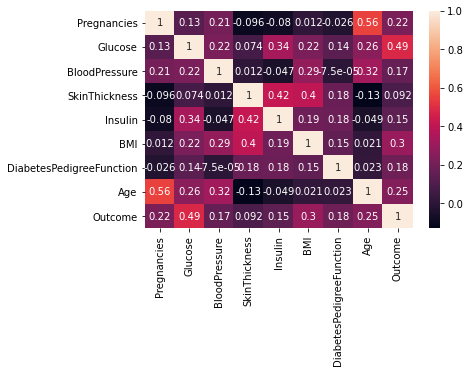

```python
import seaborn as sns
sns.heatmap(corr, annot = True)
```

### Scatter Plots

This is useful to look at the pairwise relationships from different perspectives.

Because there is little point of drawing a scatter plot of each variable with itself, the diagonal shows histograms of each attribute.

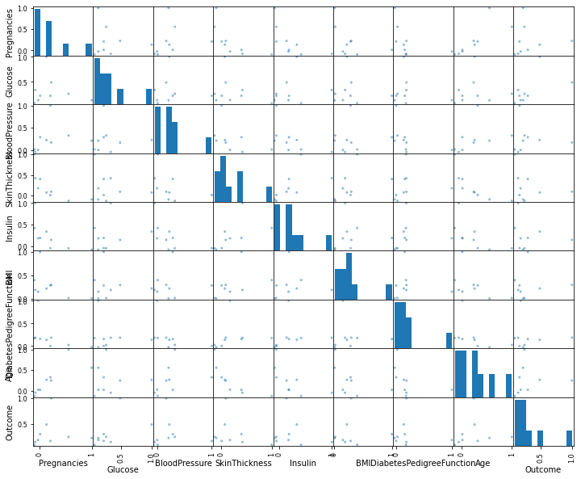

```python
import pandas
from pandas.plotting import scatter_matrix

dataCorr = my_data.corr()
pandas.plotting.scatter_matrix(dataCorr,figsize=(12,10))
pyplot.show()
```

### Feature Selection

```python
from sklearn.feature_selection import SelectKBest
from sklearn.feature_selection import chi2
test = SelectKBest(score_func=chi2, k=4)
fit = test.fit(X, Y)

set_printoptions(precision=2)
print(fit.scores_)
features = fit.transform(X)

print(features[0:5,:])
```

```
[ 111.52 1411.89   17.61   53.11 2175.57  127.67    5.39  181.3 ]
[[148.    0.   33.6  50. ]
 [ 85.    0.   26.6  31. ]
 [183.    0.   23.3  32. ]
 [ 89.   94.   28.1  21. ]
 [137.  168.   43.1  33. ]]
```

```python
The scores for each attribute and the 4 attributes chosen (those with the highest
scores): Glucose, Insulin, BMI and Age.
```

Pregnancies Glucose BloodPressure SkinThickness Insulin BMI DiabetesPedigreeFunction Age  
111.52 1411.89 17.61 53.11 2175.57 127.67 5.39 181.3

```python
from sklearn.feature_selection import RFE
from sklearn.linear_model import LogisticRegression

model = LogisticRegression()
rfe = RFE(model, 3)
fit = rfe.fit(X, Y)
print(fit.n_features_)
print(fit.support_)
print(fit.ranking_)
```

```
3
[ True False False False False  True  True False]
[1 2 3 6 5 1 1 4]
```

You can see that RFE chose the top 3 features as Pregnencies, BMI and DiabetisPedigreeFunction.

These are marked True in the support array and marked with a choice 1 in the ranking array.

Again, you can manually map the feature indexes to the indexes of attribute names.

```python
import warnings
warnings.filterwarnings("ignore")
```

```python
from sklearn.ensemble import ExtraTreesClassifier
model = ExtraTreesClassifier()
model.fit(X, Y)
print(model.feature_importances_)
```

[output not shown]

The scores suggest at the importance of Glucose, Age and BMI.

Pregnancies Glucose BloodPressure SkinThickness Insulin BMI DiabetesPedigreeFunction Age  
0.1 0.21 0.1 0.07 0.07 0.15 0.14 0.15

### Dividing Data Set

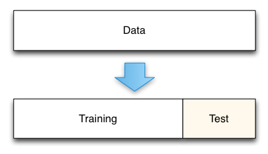

```python
from IPython.display import Image
Image(filename='3.png')
```

```python
from sklearn.model_selection import train_test_split
feature_names = ['Pregnancies', 'Glucose', 'BloodPressure', 'SkinThickness', 'Insulin', 'BMI', 'DiabetesPedigreeFunction', 'Age']
X = my_data[feature_names]
y = my_data.Outcome

X_train, X_test, Y_train, Y_test = train_test_split(X, Y)
```

### Feature Importance

Feature importance rates how important each feature is for the decision a tree makes.

It is a number between 0 and 1 for each feature, where 0 means “not used at all” and 1 means “perfectly predicts the target”.

The feature importances always sum to 1:

```python
from sklearn.tree import DecisionTreeClassifier
tree = DecisionTreeClassifier(random_state=0)
tree.fit(X_train, Y_train)
print("Accuracy on training set: {:.3f}".format(tree.score(X_train, Y_train)))
print("Accuracy on test set: {:.3f}".format(tree.score(X_test, Y_test)))
```

```
Accuracy on training set: 1.000
Accuracy on test set: 0.624
```

The accuracy on the training set is 100%, while the test set accuracy is much worse.

This is an indicative that the tree is overfitting and not generalizing well to new data.

Therefore, we need to apply pre-pruning to the tree.

We set max_depth=3, limiting the depth of the tree decreases overfitting.

This leads to a lower accuracy on the training set, but an improvement on the test set.

```python
tree = DecisionTreeClassifier(max_depth=3, random_state=0)
tree.fit(X_train, Y_train)
print("Accuracy on training set: {:.3f}".format(tree.score(X_train, Y_train)))
print("Accuracy on test set: {:.3f}".format(tree.score(X_test, Y_test)))
```

```
Accuracy on training set: 0.786
Accuracy on test set: 0.746
```

```python
print("Feature importances:\n{}".format(tree.feature_importances_))
```

```
Feature importances:
[0.09 0.6  0.   0.   0.   0.2  0.   0.1 ]
```

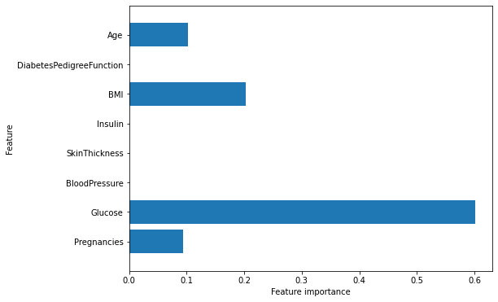

```python
import matplotlib.pyplot as plt
%matplotlib inline

def plot_feature_importances_diabetes(model):
    plt.figure(figsize=(8,6))
    n_features = 8
    plt.barh(range(n_features), model.feature_importances_, align='center')
    plt.yticks(np.arange(n_features), feature_names)
    plt.xlabel("Feature importance")
    plt.ylabel("Feature")
    plt.ylim(-1, n_features)
plot_feature_importances_diabetes(tree)
plt.savefig('feature_importance')
```

Feature “Glucose” is by far the most important feature

Apply a random forest consisting of 100 trees on the diabetes

```python
from sklearn.ensemble import RandomForestClassifier
rf = RandomForestClassifier(n_estimators=100, random_state=0)
rf.fit(X_train, Y_train)
print("Accuracy on training set: {:.3f}".format(rf.score(X_train, Y_train)))
print("Accuracy on test set: {:.3f}".format(rf.score(X_test, Y_test)))
```

```
Accuracy on training set: 1.000
Accuracy on test set: 0.740
```

```python
rf1 = RandomForestClassifier(max_depth=3, n_estimators=100, random_state=0)
rf1.fit(X_train, Y_train)
print("Accuracy on training set: {:.3f}".format(rf1.score(X_train, Y_train)))
print("Accuracy on test set: {:.3f}".format(rf1.score(X_test, Y_test)))
```

```
Accuracy on training set: 0.805
Accuracy on test set: 0.735
```

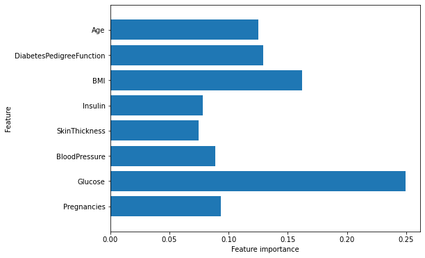

```python
plot_feature_importances_diabetes(rf)
```

Similarly to the single decision tree, the random forest also gives a lot of importance to the “Glucose” feature, but it also chooses “BMI” to be the 2nd most informative feature overall.

```python
from sklearn.ensemble import GradientBoostingClassifier
gb = GradientBoostingClassifier(random_state=0)
gb.fit(X_train, Y_train)
print("Accuracy on training set: {:.3f}".format(gb.score(X_train, Y_train)))
print("Accuracy on test set: {:.3f}".format(gb.score(X_test, Y_test)))
```

```
Accuracy on training set: 0.941
Accuracy on test set: 0.702
```

```python
gb1 = GradientBoostingClassifier(random_state=0, max_depth=1)
gb1.fit(X_train, Y_train)
print("Accuracy on training set: {:.3f}".format(gb1.score(X_train, Y_train)))
print("Accuracy on test set: {:.3f}".format(gb1.score(X_test, Y_test)))
```

```
Accuracy on training set: 0.812
Accuracy on test set: 0.729
```

```python
gb2 = GradientBoostingClassifier(random_state=0, learning_rate=0.01)
gb1.fit(X_train, Y_train)
print("Accuracy on training set: {:.3f}".format(gb1.score(X_train, Y_train)))
print("Accuracy on test set: {:.3f}".format(gb1.score(X_test, Y_test)))
```

```
Accuracy on training set: 0.812
Accuracy on test set: 0.729
```

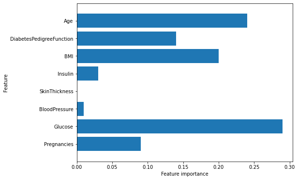

```python
plot_feature_importances_diabetes(gb1)
```

```python
from sklearn.neural_network import MLPClassifier
mlp = MLPClassifier(random_state=42)
mlp.fit(X_train, Y_train)
print("Accuracy on training set: {:.2f}".format(mlp.score(X_train, Y_train)))
print("Accuracy on test set: {:.2f}".format(mlp.score(X_test, Y_test)))
```

```
Accuracy on training set: 0.73
Accuracy on test set: 0.63
```

```python
from sklearn.preprocessing import StandardScaler
scaler = StandardScaler()
X_train_scaled = scaler.fit_transform(X_train)
X_test_scaled = scaler.fit_transform(X_test)
mlp = MLPClassifier(random_state=0)
mlp.fit(X_train_scaled, Y_train)
print("Accuracy on training set: {:.3f}".format(mlp.score(X_train_scaled, Y_train)))
print("Accuracy on test set: {:.3f}".format(mlp.score(X_test_scaled, Y_test)))
```

```
Accuracy on training set: 0.831
Accuracy on test set: 0.751
```

```python
mlp = MLPClassifier(max_iter=1000, random_state=0)
mlp.fit(X_train_scaled, Y_train)
print("Accuracy on training set: {:.3f}".format(mlp.score(X_train_scaled, Y_train)))
print("Accuracy on test set: {:.3f}".format(mlp.score(X_test_scaled, Y_test)))
```

```
Accuracy on training set: 0.913
Accuracy on test set: 0.663
```

```python
mlp = MLPClassifier(max_iter=1000, alpha=1, random_state=0)
mlp.fit(X_train_scaled, Y_train)
print("Accuracy on training set: {:.3f}".format(mlp.score(X_train_scaled, Y_train)))
print("Accuracy on test set: {:.3f}".format(mlp.score(X_test_scaled, Y_test)))
```

```
Accuracy on training set: 0.818
Accuracy on test set: 0.740
```

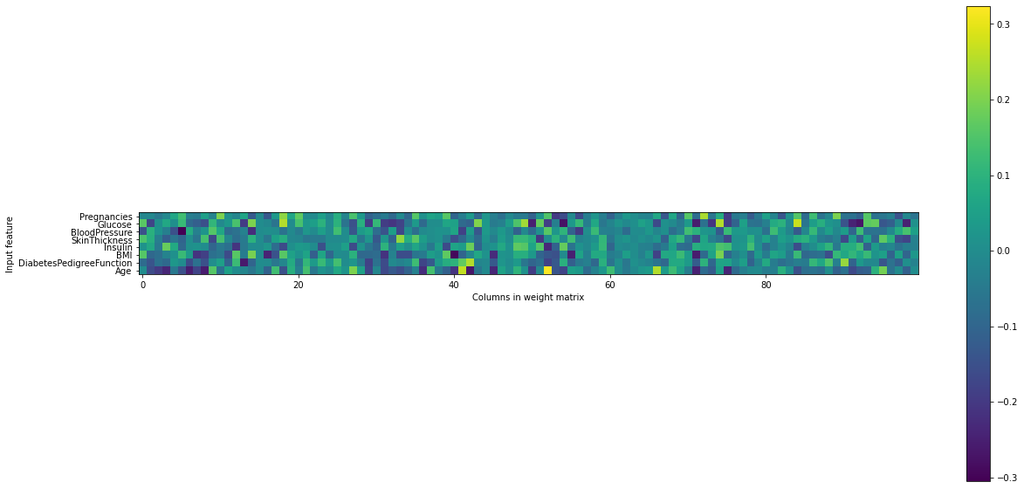

```python
plt.figure(figsize=(20, 10))
plt.imshow(mlp.coefs_[0], interpolation='none', cmap='viridis')
plt.yticks(range(8), feature_names)
plt.xlabel("Columns in weight matrix")
plt.ylabel("Input feature")
plt.colorbar()
```

### Model Building

```python
from sklearn.linear_model import LogisticRegression
from sklearn.metrics import accuracy_score
model = LogisticRegression()
model.fit(X_train, Y_train)
y_pred = model.predict(X_test)
print(accuracy_score(Y_test, y_pred))
```

```
0.7182320441988951
```

### Model Evaluation

```python
from sklearn.metrics import classification_report, confusion_matrix
print(confusion_matrix(Y_test,y_pred))
```

```
[[102  10]
 [ 41  28]]
```

```python
print(classification_report(Y_test, y_pred))
```

```
             precision    recall  f1-score   support

        0.0       0.71      0.91      0.80       112
        1.0       0.74      0.41      0.52        69

avg / total       0.72      0.72      0.69       181
```

### Predicting Unknown var

```python
new_df = pd.DataFrame([[6, 168, 72, 35, 0, 43.6, 0.627, 65]])

new_df_scaled = scaler.transform(new_df)
```

```python
prediction = model.predict(new_df_scaled)
prediction
```

```
array([0.])
```

### Comparitive Study of Classifiers

```python
import warnings
warnings.filterwarnings('ignore')
```

```python
from sklearn.linear_model import LogisticRegression
from sklearn.neighbors import KNeighborsClassifier
from sklearn.naive_bayes import GaussianNB
from sklearn.svm import SVC
from sklearn.svm import LinearSVC
from sklearn.ensemble import RandomForestClassifier
from sklearn.tree import DecisionTreeRegressor
```

```python
from sklearn import model_selection
```

```python
models = []
models.append(('LR', LogisticRegression()))
models.append(('KNN', KNeighborsClassifier()))
models.append(('NB', GaussianNB()))
models.append(('SVC', SVC()))
models.append(('LSVC', LinearSVC()))
models.append(('RFC', RandomForestClassifier()))
models.append(('DTR', DecisionTreeRegressor()))
```

```python
seed = 7
results = []
names = []
X = X
Y = y
```

```python
for name, model in models:
    kfold = model_selection.KFold(
        n_splits=10, random_state=seed)
    cv_results = model_selection.cross_val_score(
        model, X, Y, cv=kfold, scoring='accuracy')
    results.append(cv_results)
    names.append(name)
    msg = "%s: %f (%f)" % (
        name, cv_results.mean(), cv_results.std())
    print(msg)
```

```
LR: 0.766781 (0.049662)
KNN: 0.719787 (0.070349)
NB: 0.757021 (0.042590)
SVC: 0.656279 (0.070644)
LSVC: 0.624125 (0.146012)
RFC: 0.752816 (0.046399)
DTR: 0.694844 (0.057436)
```

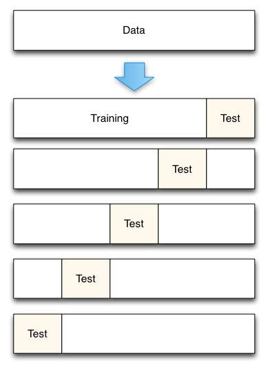

```python
from IPython.display import Image
Image(filename='4.png')
```

```python
from pandas import read_csv
from sklearn.model_selection import KFold
from sklearn.model_selection import cross_val_score
from sklearn.pipeline import Pipeline
from sklearn.pipeline import FeatureUnion
from sklearn.linear_model import LogisticRegression
from sklearn.decomposition import PCA
from sklearn.feature_selection import SelectKBest
# load data

data = pd.read_csv('diabetes.csv')
print(data.shape)

array = data.values
X = array[:,0:8]
Y = array[:,8]
# create feature union
features = []
features.append(('pca', PCA(n_components=3)))
features.append(('select_best', SelectKBest(k=6)))
feature_union = FeatureUnion(features)
# create pipeline
estimators = []
estimators.append(('feature_union', feature_union))
estimators.append(('logistic', LogisticRegression()))
model = Pipeline(estimators)
# evaluate pipeline
kfold = KFold(n_splits=10, random_state=7)
results = cross_val_score(model, X, Y, cv=kfold)
print(results.mean()*100)
```

```
(768, 9)
77.60423786739577
```

```python
from pandas import read_csv
from sklearn.model_selection import train_test_split
from sklearn.linear_model import LogisticRegression
from sklearn.externals.joblib import dump
from sklearn.externals.joblib import load


data = pd.read_csv('diabetes.csv')
#print(data.shape)

array = data.values

X = array[:,0:8]
Y = array[:,8]
X_train, X_test, Y_train, Y_test = train_test_split(X, Y, test_size=0.33, random_state=7)
# Fit the model on 33%
model = LogisticRegression()
model.fit(X_train, Y_train)

filename = 'finalized_model.sav'
dump(model, filename)

loaded_model = load(filename)
result = loaded_model.score(X_test, Y_test)
print(result)
```

```
0.7559055118110236
```